**NAGARJUNA LOKARAJU**

**Regression Analysis - Project Report**  
Northeastern University  
Date: 08 July, 2023

Introduction

**Simple Linear Regression**

To summarize the relationship and to study them between two quantitative variables, the statistical method called simple linear regression is used. Either of the two variable one would be independent variable which is not depended on any other factor and the other is the dependent variable which is influenced by the dependent variable. The graphical representation consists independent variable on X axis and dependent on Y axis. (1)

Formula

a=bx+d, where a is dependent variable , x is a variable which is independent, b is the slope and intercept is d.

If one variable value is provided , we can estimate the other, given that they are connected to each other, this process is regression.

**Multiple Linear Regression**

It’s a statistical strategy for defining the relationship between a large number of variables which are independent and a dependent single variable. Major purpose of Multiple linear regression analysis and its objective is to determine the dependent variable value using known independent variables. The weights of each indicator value indicate how big of an influence it has on the overall estimate.

**History about both**

Sir Francis Galton is known for creating the present concepts of regression analysis. He started analyzing the sweet pea plant’s qualities. He chose this as daughter plants are expressing different characteristics which are not part of the parent plant and there are no contributions from the other plant. Galton first compared the size of daughter peas with that of the mother peas and started plotting the two dimensional graph. This idea of his initial thought is considered to be the basics of regression and Sir Karl Pearson took this study ahead and published related improvements, from then it is called Pearson Product Moment Correlation. (2) Many references show that it was also developed to a large extent by Karl Gauss in 18th century.

[figure not shown]

Sir Francis Galton

**Importance and example in an industry**

Be it simple regression or a multi-variable regression, in any industry it helps the leadership to understand and evaluate the relations between the variables, accordingly the business decisions can be made.

Here considering the finance industry as an example, simple linear regression can be used for forecasting and further financial analysis this would tell the managers as to how it will change the gross domestic product and its effect on the overall sales of the company. (4)

Another example can be in finance credit analysis, where the regression analysis can be made between the income of the person, credit rating, credit limit to offer, age of the person, employment status etc. Here if only one independent is taken to have regression with dependent then it is simple linear regression, if not we can consider it as multiple regression.(3)

All this help in understanding the failures, risk , prediction, decision making.

Task1 - Simple Linear Regression Analysis

**1.1 - Faithful Data set description.**

R has an inbuilt data set called faithful. This faithful data comprises eruptions as one coulmn and waiting time as another column. Eruptions is all about the time taken in minutes by the old faithful geyser and waiting time is about the gap between the two eruptions in minutes. It has 272 rows. Both are numeric in nature. Waiting is discrete variable while eruptions is continuous. (5)

Primary source of the data is from Härdle, W. (1991) Smoothing Techniques with Implementation in S. New York: Springer.

```r
data("faithful")

er <- faithful

erm <- mean(er$eruptions)

erw <- mean(er$waiting)
```

The mean of the eruptions is 3.487 and waiting is 70.89

**1.2**

Here we are reorganizing the columns of the data set by using subset function. Extracting the first and the last 3 records with head and tail function.

```r
Fl <- subset(er, select = c(waiting, eruptions))

A <- data.frame(rbind(head(er,3),tail(er,3)))
colnames(A) <- c("Waiting time", "Eruption time")
rownames(A) <- c("1","2","3","4","5","6")
kable(A)%>%
        kableExtra::kable_styling( position = "left", full_width = FALSE)
```

[output not shown]

**Observations**

Here, Subset functions helps us to extract the required columns of the data , and also the select sub function helps to make changes to the columns as per the selection made.

Head function and tail function gives the top and last rows of the data to the extent of specified number in the code. Here we have used 3 rows of top and 3 rows of bottom and combined them using rbind function and displayed it as a table.

**1.3**

```r
Fa <- faithful
colnames(Fa) <- c("Eruption time","Waiting time")

MeanW<- mean(Fa$`Waiting time`)
MErup <- mean(Fa$`Eruption time`)
L1 <- length(Fa$`Waiting time`)
L2 <- length(Fa$`Eruption time`)
Stnd1 <- sd(Fa$`Waiting time`)
Stnd2 <- sd(Fa$`Eruption time`)

Erup_waiting <- quantile(Fa$`Waiting time`, prob=c(0.00,0.25,0.50,0.75,1.00))
Erup_Eruptions <- round(quantile(Fa$`Eruption time`, prob=c(0.00,0.25,0.50,0.75,1.00)),2)
knitr::kable(cbind(Erup_waiting,Erup_Eruptions), caption = "<br>**Basic Quartiles Statistics**")%>%
 kableExtra::kable_styling( position = "left", full_width = FALSE, bootstrap_options = c( "striped"))
```

**Basic Quartiles Statistics**

|  | Erup_waiting | Erup_Eruptions |
| --- | --- | --- |
| 0% | 43 | 1.60 |
| 25% | 58 | 2.16 |
| 50% | 76 | 4.00 |
| 75% | 82 | 4.45 |
| 100% | 96 | 5.10 |

```r
COR1 <- cor(Fa$`Waiting time`,Fa$`Eruption time`)
DTR1 <- COR1^2

tst <- COR1*sqrt((L1-2)/(1-COR1^2))
a <- 0.01

dgfr <- L1-2

CV <- qt(1-a,dgfr)

P <- 2*pt(tst,dgfr, lower.tail = FALSE)

res <- tst>CV
```

**Observations**

   Alternative hypothesis is stating that there is relation between the variables

$$Null Hypothesis: H_0: \rho = 0$$
$$Alternative Hypothesis: H_1: \rho ≠
0$$

5. test vlaue between the variable is 34.0890399
6. As the value of the test is positive and large, it is better to take the right critical tailed test rather than a two tailed test and I woudl use the right critical value.
7. The right critical value is 2.3402381.
8. Here test value > right critical value is TRUE which means test value lies far away from the critical value ont he right and we can reject the null hypothesis.
9. From this test value and the result we can say that there qre sufficient grounds for rejecting the null hypothesis and accepting the alternate hypothesis that the variables are related to each other.

**1.4**

Here in this task we are producing a scatter plot between eruption and the waiting time by using the linear model code and abline code.

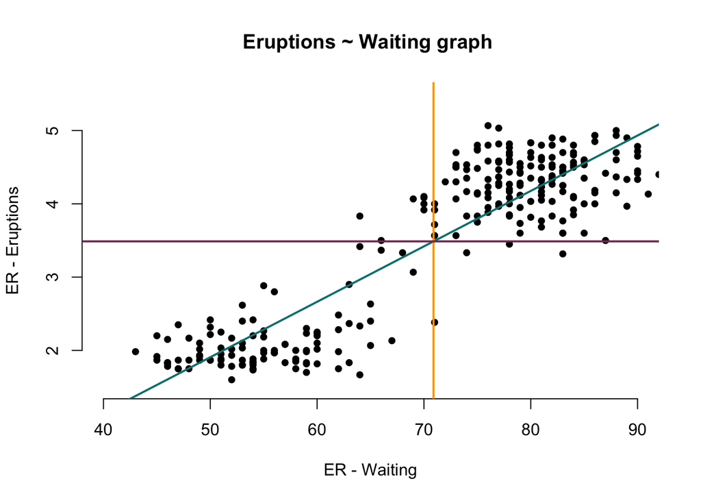

```r
plot(Fa$`Waiting time`,Fa$`Eruption time`,
     xlab= "ER - Waiting",
     main = "Eruptions ~ Waiting graph " ,
     ylab="ER - Eruptions",
     lwd=2,
     frame.plot = FALSE,
     pch=20,
     xlim=c(40,90),
     ylim=c(1.5,5.5))
abline(lm(Fa$`Eruption time`~Fa$`Waiting time`), col = "#008080", lwd=2)

lm <- lm(Fa$`Eruption time`~Fa$`Waiting time`)

abline(lwd = 2, v=mean(Fa$`Waiting time`),
       col = "orange")
abline(lwd = 2, h=mean(Fa$`Eruption time`),
       col = "#843763")
```

**Observations**

Here from the above graph we can see that the point of intersection of means is at (70.9,3.4), and regression line passing through it.

This also confirms that the regression line is correct.The regression between these two variables is Positive. we can say that they are directly proportional to each other.

**1.5**

Here in this task we are describing the summary of the linear model created in the previous task.

```r
ErS<- summary(lm)
```

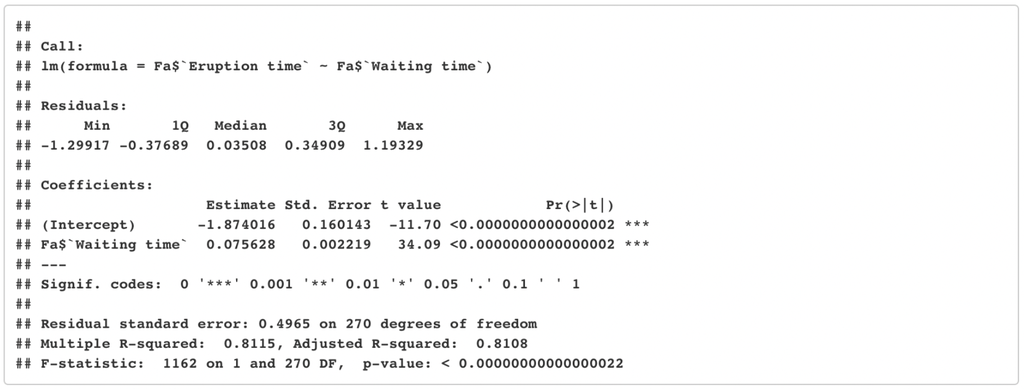

Summary

**Observations**

Summary function displays the clear and consider description of the results of the linear model. Here it is giving all the values of the basic quartiles for the linear model .

Intercept of the linear model as -1.874016

Slope of the linear model is 0.075628.

**1.6**

```r
knitr::kable(round(coefficients(summary(lm)),2), caption = "<br>**Coefficients  of model**")%>%
  kableExtra::kable_styling( position = "left",full_width = FALSE,  bootstrap_options = c( "bordered"))
```

**Coefficients of model**

|  | Estimate | Std. Error | t value | Pr(>\|t\|) |
| --- | --- | --- | --- | --- |
| (Intercept) | -1.87 | 0.16 | -11.70 | 0 |
| Fa$`Waiting time` | 0.08 | 0.00 | 34.09 | 0 |

```r
Attr <- attributes(x=lm)

knitr::kable(Attr$names, caption = "<br>**Attributes of model**")%>%
  kableExtra::kable_styling( position = "left",full_width = FALSE,  bootstrap_options = c( "basic"))
```

**Attributes of model**

| x |
| --- |
| coefficients |
| residuals |
| effects |
| rank |
| fitted.values |
| assign |
| qr |
| df.residual |
| xlevels |
| call |
| terms |
| model |

**Observations**

Fitted values are predicted values of Y.

Residuals are the difference bof the observed value and the predicted value on the regression line.

The function overall summarizes the results pertaining to the model.

Coefficients explain about the strength of the variable and the direction of it.

**1.7**

```r
faithful$Ex_pected_Y <-lm$fitted.values

RV <- round(faithful$eruptions-faithful$Ex_pected_Y,2)

faithful$Res_Value <- RV

qwer <- round(rbind(faithful[1:3,],faithful[270:272,]),2)
rownames(qwer) <- c(1,2,3,4,5,6)


knitr::kable(qwer, caption = "<br>**Expected Y and Residual Values**")%>%
  kableExtra::kable_styling(position = "left", full_width = FALSE,  bootstrap_options = c( "bordered"))
```

**Expected Y and Residual Values**

| eruptions | waiting | Ex_pected_Y | Res_Value |
| --- | --- | --- | --- |
| 3.60 | 79 | 4.10 | -0.50 |
| 1.80 | 54 | 2.21 | -0.41 |
| 3.33 | 74 | 3.72 | -0.39 |
| 4.42 | 90 | 4.93 | -0.52 |
| 1.82 | 46 | 1.60 | 0.21 |
| 4.47 | 74 | 3.72 | 0.74 |

**Observations**

Expected y values in nothing but the predicted y values which can be obtained from fitted values. Residual values is the difference of observed and expected values from fitted values.

**1.8 - formual of linear regression**

```r
a <- coefficients(summary(lm))[1]

b <- coefficients(summary(lm))[2]
```

$$\hat y = -1.874016 +
0.0756279x$$

**1.9**

```r
x1 <- 20
x2 <- 100
y1 = a+ b*x1
y2 = a+ b*x2
```

For waiting of 20 minutes, eruption expected time is: `-0.361457`

For waiting of 100 minutes, eruption expected time is: `5.6887788`

Task2 - Multiple Regression Analysis

**2.1**

```r
task2 <- read.csv("/Users/lokaraju/ALY6010 - Prob Stats/Week6 /Task2.csv")

lm1 <- lm(task2$SystolicBP~ task2$Age+task2$Weight)

tc1 <- coefficients(lm1)[1]

tc2 <- coefficients(lm1)[2]

tc3 <- coefficients(lm1)[3]

coefficients(summary(lm1))
```

```
##                 Estimate Std. Error   t value      Pr(>|t|)
## (Intercept)  55.49910188 8.81833752 6.2936015 0.00023439816
## task2$Age     1.38483955 0.17572053 7.8809205 0.00004863838
## task2$Weight  0.04221938 0.07529165 0.5607445 0.59032668718
```

$$Y=A+(B1X1)+(B2X2)$$
$$Y=55.4991019+B1 *1.3848395+B2*
0.0422194$$

**Observations**

**2.2**

```r
#b
CAS <- cor(task2$Age,task2$SystolicBP)
CWS <- cor(task2$Weight, task2$SystolicBP)
CAW <- cor(task2$Age, task2$Weight)
D1 <- CAS^2
D2 <- CWS^2
D3 <- CAW^2
CO <- rbind(CAS, CWS, CAW)
DE <- round(rbind(D1*100,D2*100,D3*100),2)
CODE <- round(cbind(CO,DE),2)
rownames(CODE) <- c( "Age~BP", "Weight~BP", "Age~Weight")
colnames(CODE) <- c("Correlation", "Determination (%) ")
CODETable <- knitr::kable(CODE, caption = "<br>**Coefficients**")%>%
  kableExtra::kable_styling( position = "left",full_width = FALSE, bootstrap_options = c( "bordered"))

#Multiple
R <- sqrt((CAS^2+CWS^2-(2*CAS*CWS*CAW))/(1-CAW^2))
Rsquare <- R^2

#Ftest
LMR <- length(task2$Age)
Ftest <- (Rsquare*(LMR-2-1))/ ((1-Rsquare)*2)
CVF <- qf(0.01, 9,8, lower.tail = FALSE)
Ftest>CVF
```

```
## [1] TRUE
```

```r
Bo1 <- 45
Bo2 <- 135
Yio1=tc1+Bo1*tc2+Bo2*tc3

Do1 <- 60
Do2 <- 182
Yio2=tc1+Do1*tc2+Do2*tc3
```

**Coefficients**

|  | Correlation | Determination (%) |
| --- | --- | --- |
| Age~BP | 0.98 | 95.78 |
| Weight~BP | 0.80 | 64.45 |
| Age~Weight | 0.80 | 63.29 |

**Observations**

The correlation between age and systolic blood pressure is high which is 0.98 , very strong and positive. Determination explains that 95 % of the changes in blood pressure are due to the age.

The correlation between weight and systolic blood pressure is high which is 0.80 but not as high as age and bp relation , it strong and positive. Determination explains that 64.45 % of the changes in blood pressure are due to weight.

The correlation between weight and age is 0.80, it strong and positive. We actually don’t calculate the independent variables relationship, and only used when doing the F test.

**2c**

Value of coefficient of multiple correlation is 0.9795076

Value of coefficient of multiple determination correlation is 95.94

**Observations**

The correlation coefficient value is higher so we can say that there is high chances of predictability of the variable systolic blood pressure which is dependent and from the variable age and weight which is independent in nature. The value is 0.97 which is closer positive 1 hence the correlation is positive between them. It is also called as Pearson correlation coefficient.

The determination value is 0.95 which explains that the modifications in BP are largely impacted by the changes in the age and weight of the person.

**F test**

The ftest value is 94.607407

The Critical Value is 5.9106188

**Observations**

The F test value is greater than the right critical value . It means that the null hypothesis which we state that there is no correlation between the independent and the dependent variables is zero can be clearly rejected. The alternate hypothesis here can be accepted, stating that the predictability of blood pressure is highly possible with the variables of weight and age.

Therefore we can say that other two variables can predict the systolic blood pressure clearly and concisely .

**Predicting values**

For a person age 45 and weight 135, we can say that, expected systolic blood pressure is 123.52

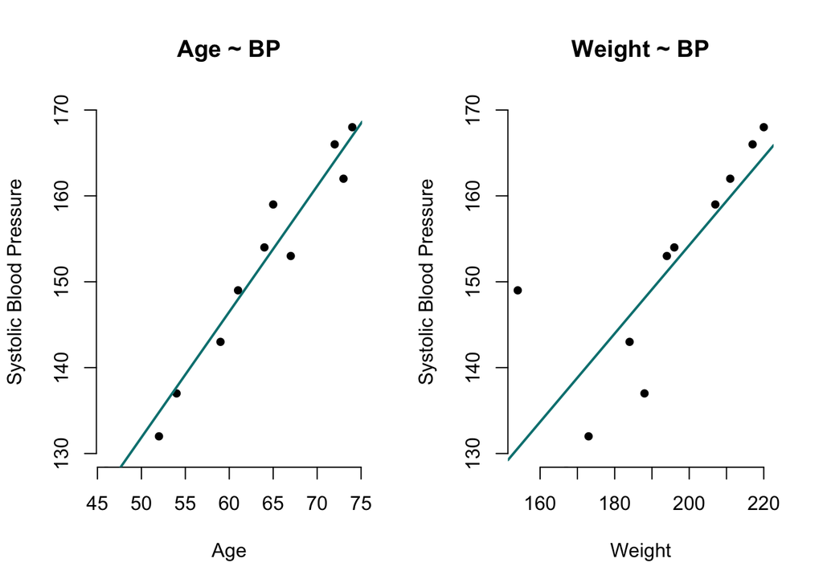

```r
par(mfrow=c(1,2))
plot(task2$Age,task2$SystolicBP, main = "Age ~ BP" , lwd=2, frame.plot = FALSE,
     pch=20, xlab = "Age", ylab = "Systolic Blood Pressure", ylim = c(130,170))
abline(lm(task2$SystolicBP~task2$Age), col = "#008080", lwd=2)

plot(task2$Weight,task2$SystolicBP, main = "Weight ~ BP" , lwd=2, frame.plot = FALSE,
     pch=20, xlab = "Weight", ylab = "Systolic Blood Pressure", ylim = c(130,170))
abline(lm(task2$SystolicBP~task2$Weight), col = "#008080", lwd=2)
```

**Observations**

Here we see that blood pressure increasing as the age and weight are increasing. Both of them have the positive coefficient with the direct relation with blood pressure.

Conclusions

**Observations**

Simple linear regression is only for one independent variable and one independent variable, as discussed in the task 1.

Multiple linear regression can be used when we have one dependent variable and manuy independent variables.

In faithful data , the eruption time and the waiting time are in direct proportion. When one increase the other also increases. Subset function helps us to extract the required columns as well as arrange them accordingly.

First quartile cuts the first 25% and the last quartile cuts the last 25% of the data when arranged in the ascending order.

correlation between eruption and waiting time is high as the coefficients of correlation and determination gives the high values and are positive in direction.

The test statistics and critical value reject the null hypothesis that there is no relationship between the two variables of eruptions.

Both the eruptions and waiting time means intersect each other and the regression line passes over it.

**New Skills gained**

In the whole course of probability and statistics the following are the skill’s gained.

1. Analysis of data from business standpoint
2. Tests to be performed basing on the size of data be it t,z, F
3. Calculating the critical values and comparing the test values and making descisions as to reject or acceo the null hypothesis.
4. Confidence intervals and its usage.
5. New Commands in R to perform all the functions

Here in this segment I have learnt

Subset function, summary function and how to extract required values, creation of regression models and graphs pertaining ot it. Coefficient of correlation and determination and how to asses the results.

6. The appropriate tests to be done basing on the test values.
7. Attributes function to give all the names of the attributes pertaining to the model.
8. How to do multiple regression analysis and using the new formulas for multiple correlation and F test. Multi R sqaured values and its interpretation.

**Recommendations**

Correlation is good test for some extent and we cannot finalise on the correlation alone for finding the cause and effect relationship.

To detect the flaws with the linear or multi regression model, residual plots should be evaluated.

To draw appropriate and best results all the details should be mentioned.

You may get good forecasts if you assess a parameter that is connected to alterations in the results but does not impact the conclusion.

Example: Vitamins can improve health but it is not a cause for the good health. Even if u change the vitamin it doesn’t improve the heath. It is a catalyst. So we have to check the if two variables have a relation of which one can cause change in other. Hence always check for the causal relationship.

Bibliography

1. 2.1 - what is simple linear regression? 2.1 - What is Simple Linear Regression? | STAT 462. (n.d.). Retrieved December 19, 2021, from https://online.stat.psu.edu/stat462/node/91/
2. Galton, Pearson, and the peas: A brief … - tandfonline.com. (n.d.). Retrieved December 19, 2021, from https://www.tandfonline.com/doi/pdf/10.1080/10691898.2001.11910537
3. 16/04/2019, A. C., Choudhury, A., Ambika ChoudhuryA Technical Journalist who loves writing about Machine Learning and…, Ambika ChoudhuryA Technical Journalist who loves writing about Machine Learning and Artificial Intelligence. A lover of music, & Choudhury, A. (2021, March 12). Why regression analysis is the backbone for enterprises. Analytics India Magazine. Retrieved December 19, 2021, from https://analyticsindiamag.com/why-regression-analysis-is-the-backbone-for-enterprises/
4. Teeboom, L. (2019, March 8). The advantages of regression analysis & forecasting. Small Business - Chron.com. Retrieved December 19, 2021, from https://smallbusiness.chron.com/advantages-regression-analysis-forecasting-61800.html
5. R: Old faithful geyser data. (n.d.). Retrieved December 19, 2021, from https://stat.ethz.ch/R-manual/R-devel/library/datasets/html/faithful.html